# P8130_HW3_Problem4

Chen Shaoxuan

11/11/2017

## a).Describe dataset and the variables of interest.

This dataset is the Global Health Observatory Data in 2012, which contains 137 entries and 12 variables of interest. The variables are country, pcgovhealth(per capital government health expend), legislation(IHR Legislation Score), coordination(IHR Coordination Score), surveillance(IHR Surveillance Score), preparedness(IHR Preparedness Score), foodsafety(IHR Food Safety Score), birthrate(Birth Rate per 1000), mlifebirth(Male Life Expectancy at ), flifebirth(Female Life Expectancy at), lifebirth(Life Expectancy at Birth), life60(Life Expectancy at Age 60). We are interested in the female life expectancy and the government health expend.

## b).Summary statistics for each of the variables of interest

| variables | n_obs | mean | sd | median | munimum | maxiun | first_Qu. | third_Qu. |
| --- | --- | --- | --- | --- | --- | --- | --- | --- |
| flifebirth | 137 | 74.74 | 8.05 | 77.0 | 53.0 | 87.0 | 70.0 | 80.0 |
| pcgovhealth | 137 | 845.77 | 1469.03 | 222.6 | 4.7 | 7704.4 | 61.6 | 643.5 |

## c)

### Graphical displays (histograms, boxplots, and scatterplots)

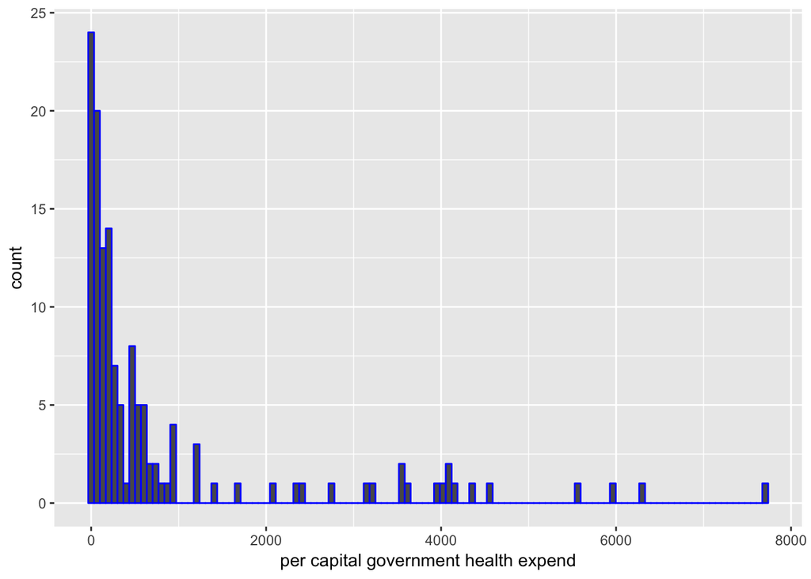

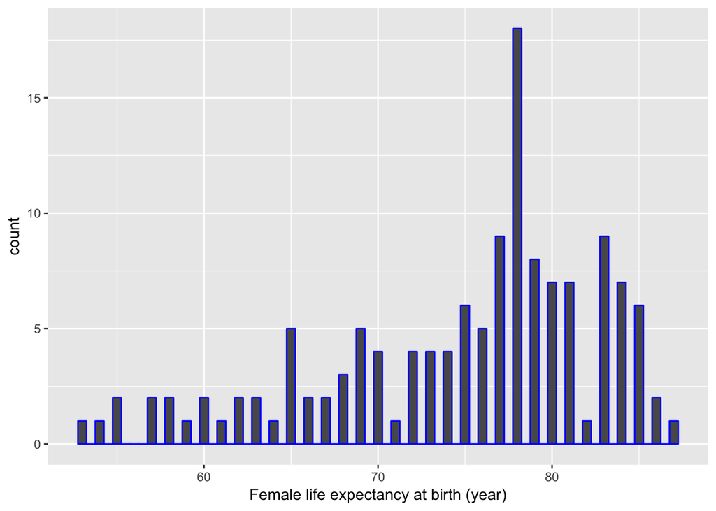

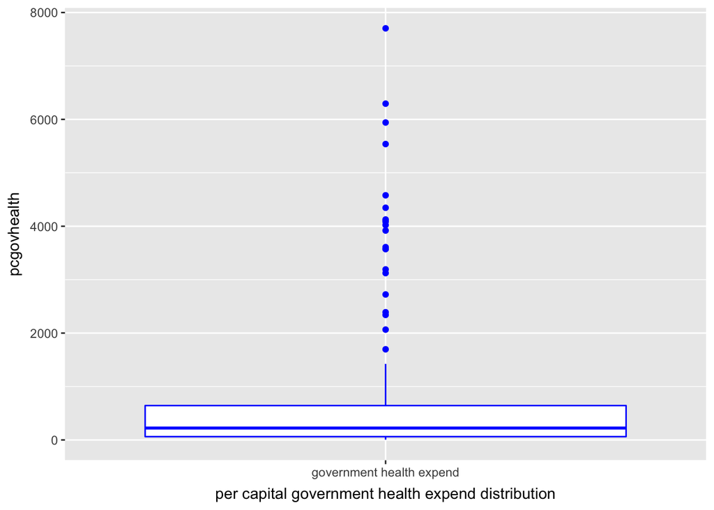

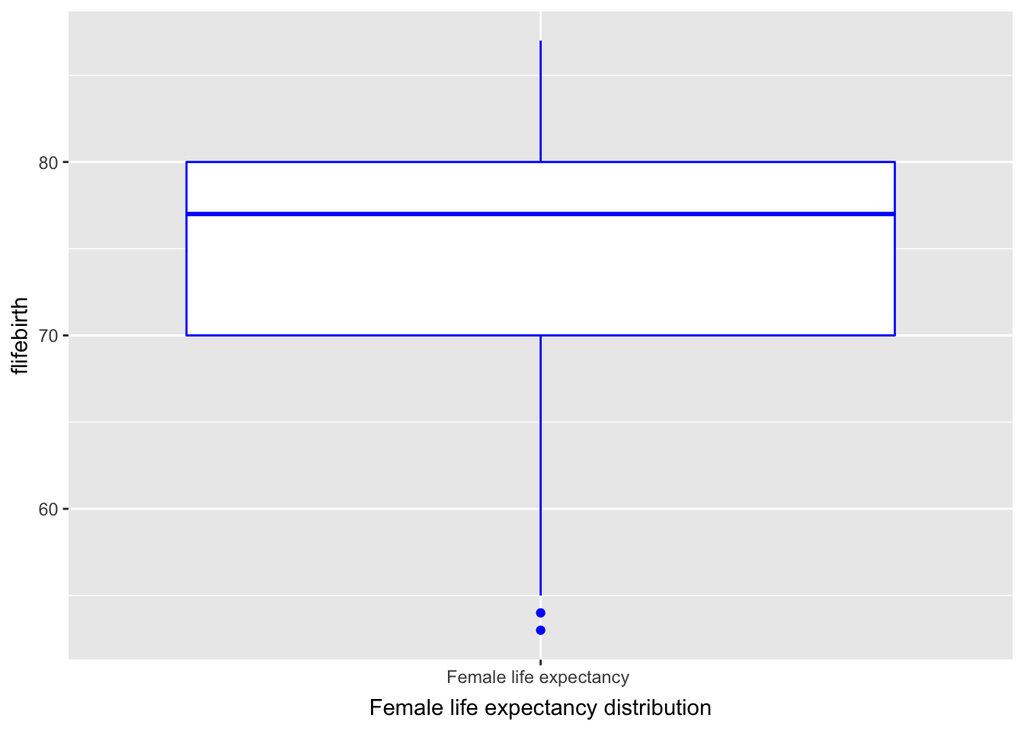

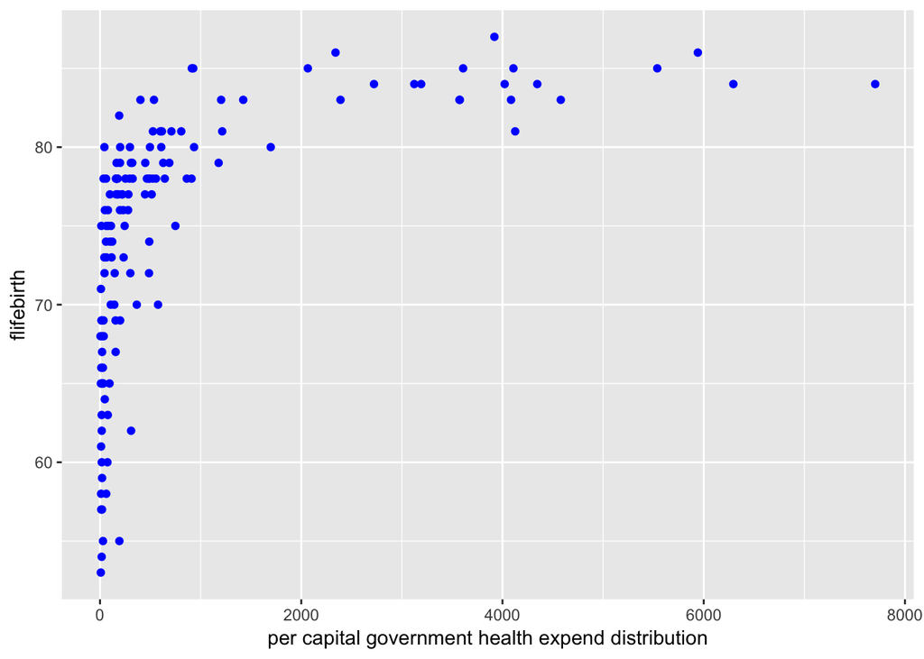

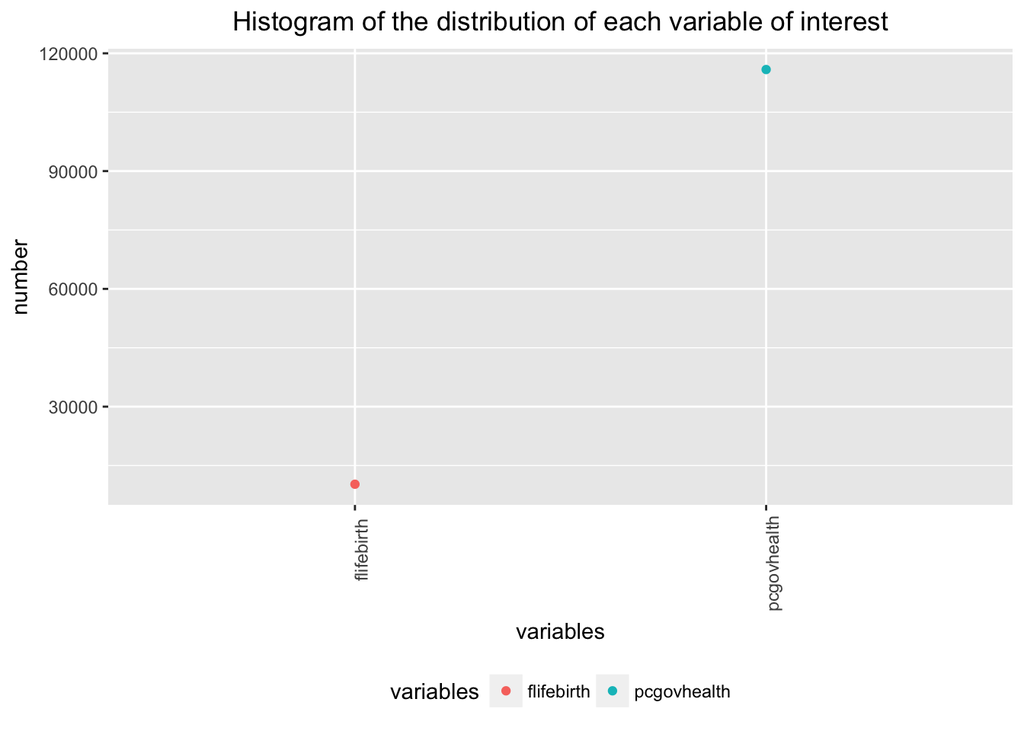

###i) Is linear regression a reasonable model for this problem? Explain why or why not.  
*From the plots, it is obvious that linear regression is not a reasonable model for this problem. Since the vairable “pcgovhealth” is very difference from the others. And in the plots the variables did not show a linear relationship with each other.

### ii) Try a natural logarithm transformation of the predictor and check the relationship.

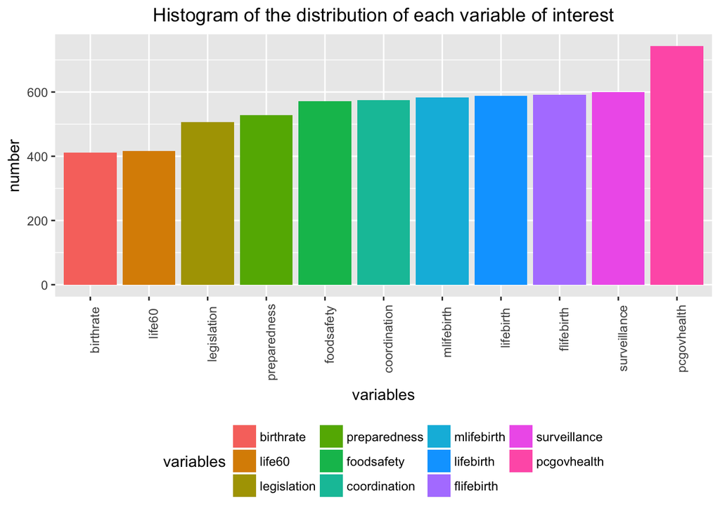

[output not shown]

```r
log_data = who_life_exp_data %>%
  na.omit() %>%
  gather(key = "variables", value = "number", pcgovhealth:life60) %>%
  mutate(number = number + 1 ) %>%
  mutate(number = log(number)) %>%
  mutate(variables = as.factor(variables)) %>%
  group_by(variables) %>%
  summarise(sum = sum(number)) %>%
  mutate(variables = fct_reorder(variables, sum))

log_data %>%
 ggplot(aes(x = variables, y = sum, fill = variables)) +
  geom_col() +
   xlab("variables") + ylab("number") +
   ggtitle("Histogram of the distribution of each variable of interest") +
  theme(legend.position = "bottom" ,
        plot.title = element_text(hjust = 0.5),              ######### make the title in the middle
        axis.text.x = element_text(angle = 90, hjust = 0.9))
```

## d). ) Fit a linear regression where female life expectancy in a country is regressed on per capita spending on health (original or transformed). (8p)

Note: If you chose a transformation of the predictor, make sure you consider it in all aspects, including interpretation.

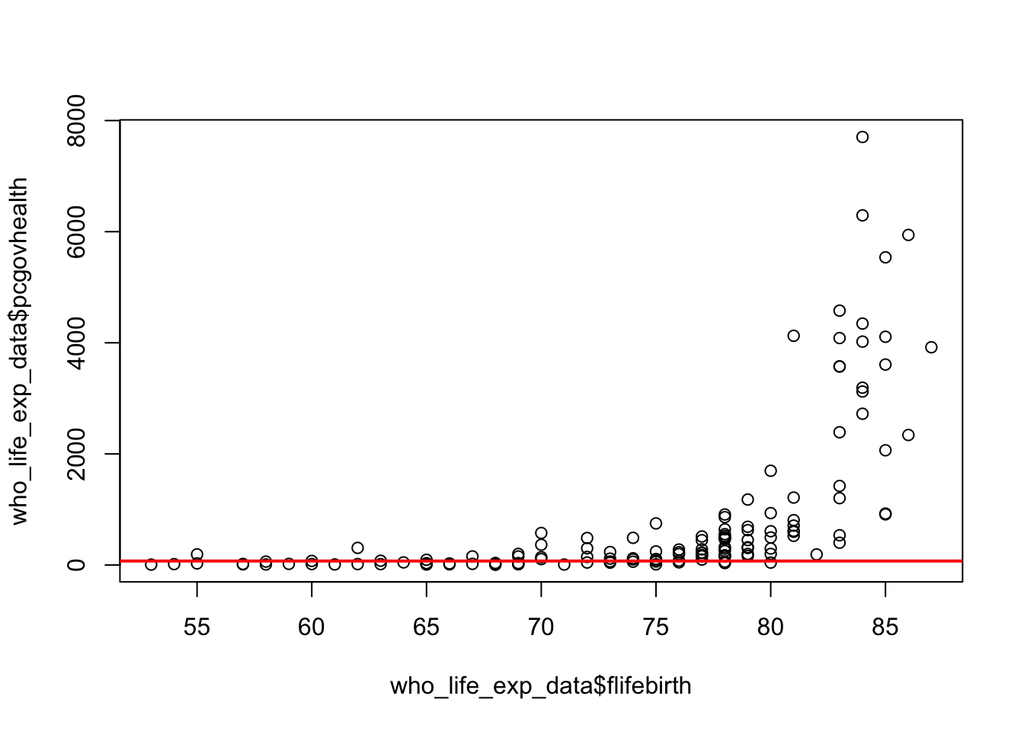

```r
#At first check the relationship between "pcgovhealth" and "flifebirth"
reg_lm1 = lm(data = who_life_exp_data,flifebirth~pcgovhealth)
plot(who_life_exp_data$flifebirth, who_life_exp_data$pcgovhealth)
abline(reg_lm1, lwd = 2, col = 2)
```

It is obvious that female life expectancy is not regressed on per capita spending on health. Thus, I choose to do logarithm transformation of the predictor.

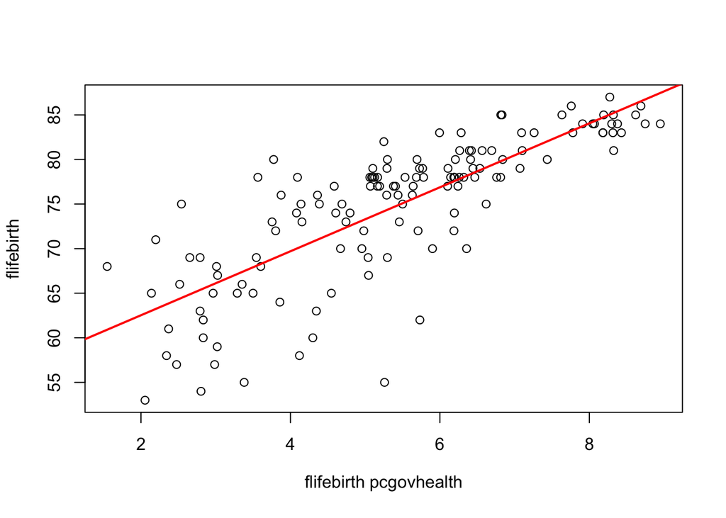

```r
pcgovhealth_flifebirth_lm_data = who_life_exp_data %>%
  select(pcgovhealth, flifebirth) %>%
  mutate(pcgovhealth = log(pcgovhealth))
##Check
reg_lm = lm(data = pcgovhealth_flifebirth_lm_data, flifebirth~pcgovhealth)
plot(pcgovhealth_flifebirth_lm_data, flifebirth~pcgovhealth)
abline(reg_lm, lwd = 2, col = 2)
```

```r
 #pcgovhealth_flifebirth_lm_data %>%
  #ggplot(aes(x = pcgovhealth, y = flifebirth, color = pcgovhealth)) +
  #geom_point(alpha = .8) +
   #ggtitle("Plot after logarithm transformation of the predictor ") +
  #theme(legend.position = "bottom" ,
   #     plot.title = element_text(hjust = 0.5))
```

#### fit the regression model

```r
reg_lm = lm(data = pcgovhealth_flifebirth_lm_data, flifebirth~pcgovhealth)
summary(reg_lm)
```

```
##
## Call:
## lm(formula = flifebirth ~ pcgovhealth, data = pcgovhealth_flifebirth_lm_data)
##
## Residuals:
##      Min       1Q   Median       3Q      Max
## -19.2254  -2.1534   0.4481   3.0027  11.1002
##
## Coefficients:
##             Estimate Std. Error t value Pr(>|t|)
## (Intercept)  55.3524     1.3490   41.03   <2e-16 ***
## pcgovhealth   3.5887     0.2372   15.13   <2e-16 ***
## ---
## Signif. codes:  0 '***' 0.001 '**' 0.01 '*' 0.05 '.' 0.1 ' ' 1
##
## Residual standard error: 4.922 on 135 degrees of freedom
## Multiple R-squared:  0.629,  Adjusted R-squared:  0.6262
## F-statistic: 228.9 on 1 and 135 DF,  p-value: < 2.2e-16
```

```r
#Calculate the 95% CI for moder parameters?
##Beta1
CI_data = pcgovhealth_flifebirth_lm_data
colnames(CI_data) <- c("x", "y")
x = CI_data$x
y = CI_data$y
b_1 = sum((x-mean(x))*(y-mean(y))) / (sum((x-mean(x))^2))
b_0 = mean(y) - b_1*mean(x)
SSE = sum((y - b_0 - b_1*x)^2)
MSE = SSE / 135
s_b1 = sqrt(MSE/(sum((x-mean(x))^2)))
s_b0 = MSE*(1/137 + (mean(x)^2)/(sum((x-mean(x))^2)))

###95% CI for b_1
CI_b_1_upper_limit = b_1 + qt(0.95, 135)*s_b1
CI_b_1_lower_limit = b_1 - qt(0.95, 135)*s_b1
###95% CI for b_0
CI_b_0_upper_limit = b_0 + qt(0.95, 135)*s_b0
CI_b_0_lower_limit = b_0 - qt(0.95, 135)*s_b0
```

### ii) Also, write the ‘best-fitting’ line equation.

The ‘best-fitting’ line equation is $\hat{Y_i}= 3.5887ln\hat{X_i} + 55.3524$

### e) Provide a point estimate and a 95% interval for the mean life expectancy for countries that have per capita spending on health of approximately 1,100 US dollars. Is this a confidence or a prediction interval? Make sure you provide its interpretation correctly. (3p)

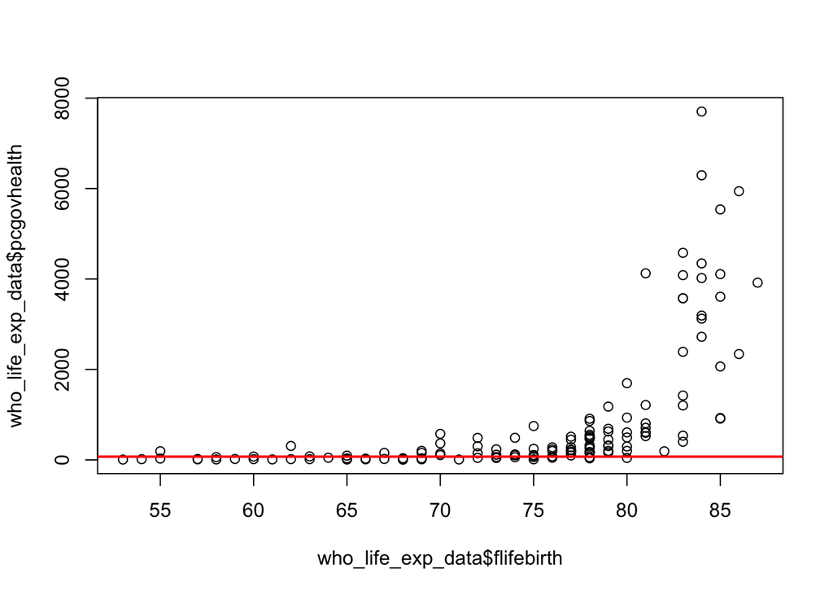

```r
plot(who_life_exp_data$flifebirth, who_life_exp_data$pcgovhealth)
abline(reg_lm1, lwd = 2, col = 2)
```

```r
#data_hosp = as.data.frame(data_hosp)
reg_lm = lm(data = pcgovhealth_flifebirth_lm_data, flifebirth~pcgovhealth)
#create a new data frame that set the beds value.
newdata=data.frame(pcgovhealth = log(1100))
#Apply the predict function and set the predictor variable in the newdata argument. We also set the interval type as "predict", and use the default 0.95 confidence level.
predict(reg_lm, newdata, interval ="prediction", level = 0.95)
```

```
##        fit      lwr      upr
## 1 80.48407 70.68525 90.28289
```